# Practical Machine Learning

Cristina Rider

10/12/2021

## Background

Using devices such as Jawbone Up, Nike FuelBand, and Fitbit it is now possible to collect a large amount of data about personal activity relatively inexpensively. These type of devices are part of the quantified self movement - a group of enthusiasts who take measurements about themselves regularly to improve their health, to find patterns in their behavior, or because they are tech geeks. One thing that people regularly do is quantify how much of a particular activity they do, but they rarely quantify how well they do it. In this project, your goal will be to use data from accelerometers on the belt, forearm, arm, and dumbell of 6 participants. They were asked to perform barbell lifts correctly and incorrectly in 5 different ways. More information is available from the website here: http://groupware.les.inf.puc-rio.br/har (see the section on the Weight Lifting Exercise Dataset)."

## Data

The data for this project come from this source: http://groupware.les.inf.puc-rio.br/har. The information has been generously provided for use use in this cousera course by the authors, Velloso, E.; Bulling, A.; Gellersen, H.; Ugulino, W.; Fuks, H. They have allowed the use of their paper “Qualitative Activity Recognition of Weight Lifting Exercises. Proceedings of 4th International Conference in Cooperation with SIGCHI (Augmented Human ’13) . Stuttgart, Germany: ACM SIGCHI, 2013.

The training data for this project are available here:

https://d396qusza40orc.cloudfront.net/predmachlearn/pml-training.csv

The test data are available here:

https://d396qusza40orc.cloudfront.net/predmachlearn/pml-testing.csv

# Choosing the prediction algorithm

Steps Taken

```r
## install.packages("pacman")
pacman::p_load(ggplot2, caret, randomForest, gbm, e1071, doParallel, survival, splines, plyr, dplyr)
```

# Load Data

1. Load the data
2. Remove #DIV/0!, replace with NA

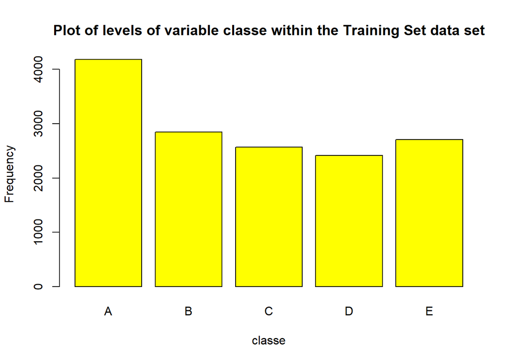

```r
## Load data
training <- read.csv("C:/Users/cristina.rider/Desktop/Training/Kaggle/pml_training.csv", na.strings=c("#DIV/0!", "NA", ""), row.names = 1)
testing <- read.csv("C:/Users/cristina.rider/Desktop/Training/Kaggle/pml_testing.csv", na.strings=c("#DIV/0!", "NA", ""), row.names = 1)

# remove columns with >95% missing values
training <- training[, which(colMeans(!is.na(training)) > .95)]
testing <- testing[, which(colMeans(!is.na(testing)) > .95)]

# remove irrelevant columns
training <- training[, -c(1:7)]
testing <- testing[, -c(1:7)]

#Partition training into 75% train and 25% validation
inTrain <- createDataPartition(training$classe, p = 0.75, list = F)
trainingset <- training[inTrain, ]
validationset <- training[-inTrain, ]


plot(x = trainingset$classe, col="yellow", main="Plot of levels of variable classe within the Training Set data set", xlab="classe", ylab="Frequency")
```

```r
#Train 3 different models
mod1 <- train(classe ~ ., data=trainingset, method="rf")
#mod2 <- train(classe ~ ., data=trainingset, method="gbm")
#mod3 <- train(classe ~ ., data=trainingset, method="lda")

pred1 <- predict(mod1, validationset)
#pred2 <- predict(mod2, validationset)
#pred3 <- predict(mod3, validationset)

#show confusion matrices

#99.5% accuracy
confusionMatrix(pred1, validationset$classe)
```

```
## Confusion Matrix and Statistics
##
##           Reference
## Prediction    A    B    C    D    E
##          A 1394    2    0    0    0
##          B    1  943    7    0    0
##          C    0    3  848   11    1
##          D    0    0    0  791    0
##          E    0    1    0    2  900
##
## Overall Statistics
##
##                Accuracy : 0.9943
##                  95% CI : (0.9918, 0.9962)
##     No Information Rate : 0.2845
##     P-Value [Acc > NIR] : < 2.2e-16
##
##                   Kappa : 0.9928
##
##  Mcnemar's Test P-Value : NA
##
## Statistics by Class:
##
##                      Class: A Class: B Class: C Class: D Class: E
## Sensitivity            0.9993   0.9937   0.9918   0.9838   0.9989
## Specificity            0.9994   0.9980   0.9963   1.0000   0.9993
## Pos Pred Value         0.9986   0.9916   0.9826   1.0000   0.9967
## Neg Pred Value         0.9997   0.9985   0.9983   0.9968   0.9998
## Prevalence             0.2845   0.1935   0.1743   0.1639   0.1837
## Detection Rate         0.2843   0.1923   0.1729   0.1613   0.1835
## Detection Prevalence   0.2847   0.1939   0.1760   0.1613   0.1841
## Balanced Accuracy      0.9994   0.9958   0.9941   0.9919   0.9991
```

```r
#96% accuracy
#confusionMatrix(pred2, validationset$classe)
#69% accuracy
#confusionMatrix(pred3, validationset$classe)

#Create Combination Model
#predDF <- data.frame(pred1, pred2, pred3, classe=validationset$classe)
#predDF <- data.frame(pred1, pred2, classe=validationset$classe)
#combModFit <- train(classe ~ ., method="rf", data=predDF)

#in-sample error
#combPredIn <- predict(combModFit, predDF)
#confusionMatrix(combPredIn, predDF$classe)

#out-of-sample error
```

# Fine Tuning

Assess Number of relevant variables

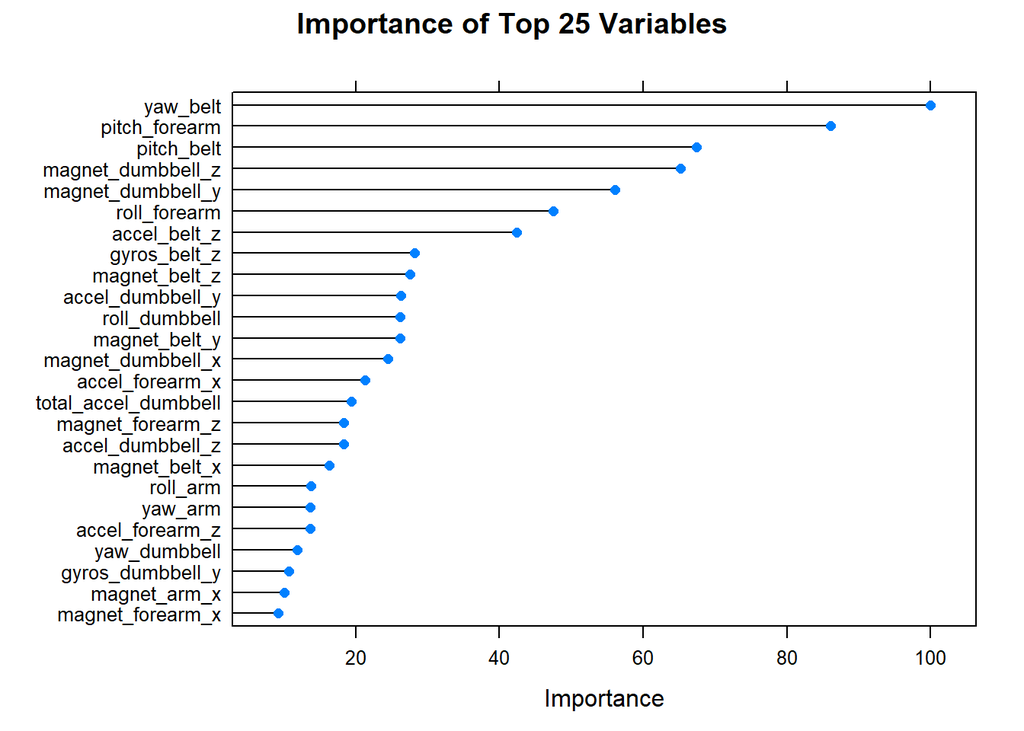

```r
varImpRF <- mod1

varImpObj <- varImp(varImpRF)
# Top 40 plot
#plot(varImpObj, main = "Importance of Top 40 Variables", top = 40)

# Top 25 plot
plot(varImpObj, main = "Importance of Top 25 Variables", top = 25)
```

## Conclusion

I stopped at this stage as the goal to be able to get the required answers and report the errors achieved with the model has been reached without any further fine tuning.

The Random Forest method worked very well.

This model will be used for the final calculations.

The logic behind using the random forest method as the predictor rather than other methods or a combination of various methods is:

1. Random forests are suitable when to handling a large number of inputs, especially when the interactions between variables are unknown.
2. Random forest’s built in cross-validation component that gives an unbiased estimate of the forest’s out-of-sample (or bag) (OOB) error rate.
3. A Random forest can handle unscaled variables and categorical variables. This is more forgiving with the cleaning of the data.

# Prepare the submission

```r
pml_write_files = function(x){
n = length(x)
for(i in 1:n){
filename = paste0("problem_id_",i,".txt")
write.table(x[i],file=filename,quote=FALSE,row.names=FALSE,col.names=FALSE)
}
}
x <- testing
answers <- predict(mod1, newdata=x)
answers
```

```
##  [1] B A B A A E D B A A B C B A E E A B B B
## Levels: A B C D E
```

```r
pml_write_files(answers)
```